# Titanic Survival Analysis

Jirawan Phromtawepong

2025-06-12

# 1 🛳 Introduction

This project explores survival patterns in the Titanic dataset using R. The analysis focuses on how **gender**, **passenger class**, and **family presence** influenced the likelihood of survival.

The goal is to demonstrate end-to-end data analysis skills: from data cleaning and transformation to visualization and insight generation. This project is part of my data portfolio to showcase my analytical thinking and ability to communicate findings.

# 2 📦 Dataset Overview

```r
library(readr)
library(dplyr)
library(ggplot2)
```

```r
titanic <- read_csv("titanic.csv")
glimpse(titanic)
```

```
## Rows: 891
## Columns: 12
## $ PassengerId <dbl> 1, 2, 3, 4, 5, 6, 7, 8, 9, 10, 11, 12, 13, 14, 15, 16, 17,…
## $ Survived    <dbl> 0, 1, 1, 1, 0, 0, 0, 0, 1, 1, 1, 1, 0, 0, 0, 1, 0, 1, 0, 1…
## $ Pclass      <dbl> 3, 1, 3, 1, 3, 3, 1, 3, 3, 2, 3, 1, 3, 3, 3, 2, 3, 2, 3, 3…
## $ Name        <chr> "Braund, Mr. Owen Harris", "Cumings, Mrs. John Bradley (Fl…
## $ Sex         <chr> "male", "female", "female", "female", "male", "male", "mal…
## $ Age         <dbl> 22, 38, 26, 35, 35, NA, 54, 2, 27, 14, 4, 58, 20, 39, 14, …
## $ SibSp       <dbl> 1, 1, 0, 1, 0, 0, 0, 3, 0, 1, 1, 0, 0, 1, 0, 0, 4, 0, 1, 0…
## $ Parch       <dbl> 0, 0, 0, 0, 0, 0, 0, 1, 2, 0, 1, 0, 0, 5, 0, 0, 1, 0, 0, 0…
## $ Ticket      <chr> "A/5 21171", "PC 17599", "STON/O2. 3101282", "113803", "37…
## $ Fare        <dbl> 7.2500, 71.2833, 7.9250, 53.1000, 8.0500, 8.4583, 51.8625,…
## $ Cabin       <chr> NA, "C85", NA, "C123", NA, NA, "E46", NA, NA, NA, "G6", "C…
## $ Embarked    <chr> "S", "C", "S", "S", "S", "Q", "S", "S", "S", "C", "S", "S"…
```

```r
summary(titanic)
```

```
##   PassengerId       Survived          Pclass          Name
##  Min.   :  1.0   Min.   :0.0000   Min.   :1.000   Length:891
##  1st Qu.:223.5   1st Qu.:0.0000   1st Qu.:2.000   Class :character
##  Median :446.0   Median :0.0000   Median :3.000   Mode  :character
##  Mean   :446.0   Mean   :0.3838   Mean   :2.309
##  3rd Qu.:668.5   3rd Qu.:1.0000   3rd Qu.:3.000
##  Max.   :891.0   Max.   :1.0000   Max.   :3.000
##
##      Sex                 Age            SibSp           Parch
##  Length:891         Min.   : 0.42   Min.   :0.000   Min.   :0.0000
##  Class :character   1st Qu.:20.12   1st Qu.:0.000   1st Qu.:0.0000
##  Mode  :character   Median :28.00   Median :0.000   Median :0.0000
##                     Mean   :29.70   Mean   :0.523   Mean   :0.3816
##                     3rd Qu.:38.00   3rd Qu.:1.000   3rd Qu.:0.0000
##                     Max.   :80.00   Max.   :8.000   Max.   :6.0000
##                     NA's   :177
##     Ticket               Fare           Cabin             Embarked
##  Length:891         Min.   :  0.00   Length:891         Length:891
##  Class :character   1st Qu.:  7.91   Class :character   Class :character
##  Mode  :character   Median : 14.45   Mode  :character   Mode  :character
##                     Mean   : 32.20
##                     3rd Qu.: 31.00
##                     Max.   :512.33
##
```

# 3 🧹 Data Cleaning & Preparation

```r
titanic_clean <- titanic %>%
  filter(!is.na(Age)) %>%
  mutate(
    FamilySize = SibSp + Parch,
    TravelAlone = ifelse(FamilySize == 0, "Alone", "WithFamily"),
    Survived = factor(Survived, levels = c(0,1), labels = c("Died", "Survived")),
    Pclass = factor(Pclass),
    Sex = factor(Sex)
  )
```

# 4 📊 Analysis & Visualization

## 4.1 1. Survival Rate by Gender

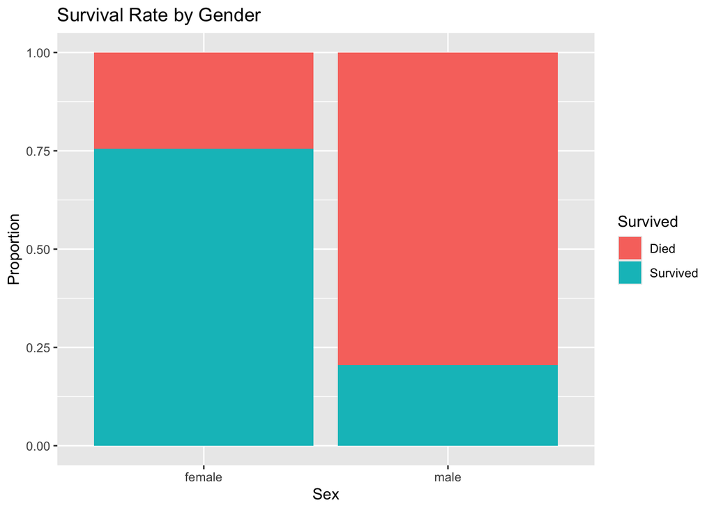

```r
ggplot(titanic_clean, aes(x = Sex, fill = Survived)) +
  geom_bar(position = "fill") +
  labs(title = "Survival Rate by Gender", y = "Proportion")
```

## 4.2 2. Survival Rate by Passenger Class

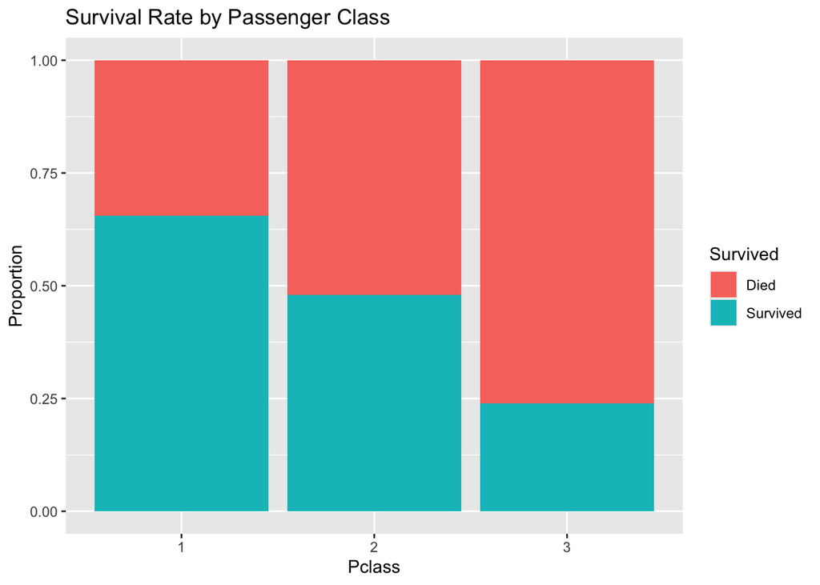

```r
ggplot(titanic_clean, aes(x = Pclass, fill = Survived)) +
  geom_bar(position = "fill") +
  labs(title = "Survival Rate by Passenger Class", y = "Proportion")
```

**Insight:**

Passengers in **1st class** had the highest survival rate, followed by 2nd class, while **3rd class** passengers had the lowest. This highlights a likely influence of **socioeconomic status** and cabin accessibility during evacuation.

## 4.3 3. Survival Rate: Traveling Alone vs With Family

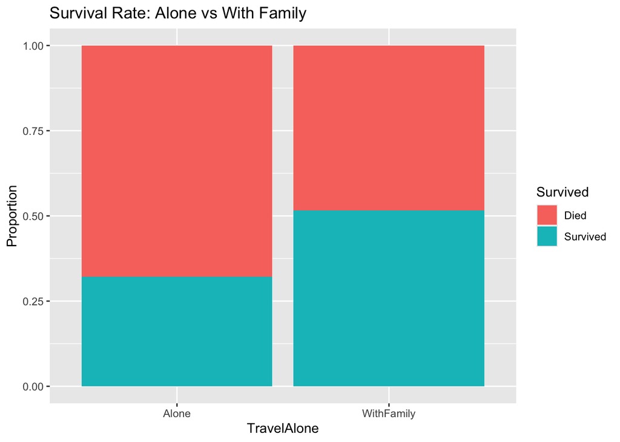

```r
ggplot(titanic_clean, aes(x = TravelAlone, fill = Survived)) +
  geom_bar(position = "fill") +
  labs(title = "Survival Rate: Alone vs With Family", y = "Proportion")
```

**Insight:**

Passengers traveling **with family** had a significantly higher survival rate than those traveling alone. This may reflect both practical support and social prioritization for groups during evacuation.

# 5 🛠 Tools Used

- **Language**: R
- **Libraries**: `readr`, `dplyr`, `ggplot2`
- **Skills Demonstrated**:
  - Data cleaning
  - Feature engineering
  - Exploratory data analysis
  - Data visualization
  - Insight communication

```
titanic-survival-analysis/
├── data/
│   └── titanic.csv
├── R/
│   └── titanic_analysis.Rmd
├── outputs/
│   └── titanic_analysis.html  # (after knitting)
├── README.md
└── LICENSE
```